# ONLINE RETAIL DATA ANALYSIS

# Total Quantity sold

```python
df['Quantity'].sum()
```

```
5167812
```

```python
Country = df.groupby('Country')['TotalAmount'].sum().sort_values(ascending=False)
```

```python
Country
```

```
Country
United Kingdom          7308391.554
Netherlands              285446.340
EIRE                     265545.900
Germany                  228867.140
France                   209024.050
Australia                138521.310
Spain                     61577.110
Switzerland               56443.950
Belgium                   41196.340
Sweden                    38378.330
Japan                     37416.370
Norway                    36165.440
Portugal                  33439.890
Finland                   22546.080
Singapore                 21279.290
Channel Islands           20450.440
Denmark                   18955.340
Italy                     17483.240
Cyprus                    13590.380
Austria                   10198.680
Poland                     7334.650
Israel                     7221.690
Greece                     4760.520
Iceland                    4310.000
Canada                     3666.380
USA                        3580.390
Malta                      2725.590
Unspecified                2667.070
United Arab Emirates       1902.280
Lebanon                    1693.880
Lithuania                  1661.060
European Community         1300.250
Brazil                     1143.600
RSA                        1002.310
Czech Republic              826.740
Bahrain                     548.400
Saudi Arabia                145.920
Name: TotalAmount, dtype: float64
```

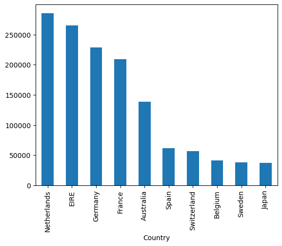

```python
Country[1:11].plot(kind="bar")
```

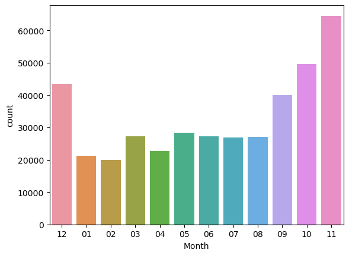

```python
sns.countplot(data=df,x="Month")
```

wendesday and thursday are days with most number of customers and orders and sales. friday and sunday have the very less number of customers and sales.

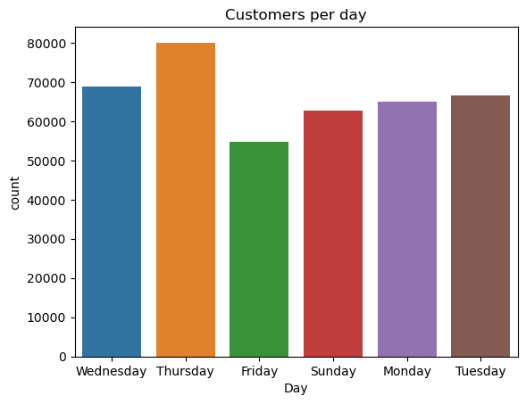

```python
sns.countplot(data=df,x='Day')
plt.title('Customers per day')
```

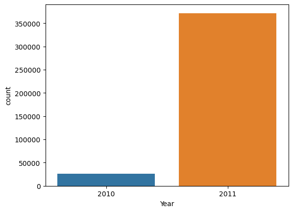

```python
sns.countplot(data=df,x='Year')
```

```python
IT=df['InvoiceTime'].value_counts()
```

```python
# Between 12 to 2 most of the orders have been geeting from the customers
```

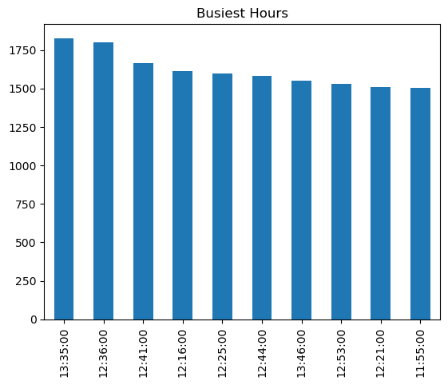

```python
IT.head(10).plot(kind='bar')
plt.title('Busiest Hours')
```

```python
customer=df.groupby('CustomerID')['TotalAmount'].count().sort_values(ascending=False)
```

```python
customer
```

```
CustomerID
17841.0    7847
14911.0    5675
14096.0    5111
12748.0    4595
14606.0    2700
           ...
17846.0       1
13017.0       1
13099.0       1
13106.0       1
12346.0       1
Name: TotalAmount, Length: 4338, dtype: int64
```

[figure not shown]

```python
customer.head(11).plot(kind='bar')
plt.title('Top 10 Customer''s' 'ID')
```

```python
product=df['Description'].value_counts().sort_values(ascending=False)
```

```python
product
```

```
WHITE HANGING HEART T-LIGHT HOLDER    2028
REGENCY CAKESTAND 3 TIER              1723
JUMBO BAG RED RETROSPOT               1618
ASSORTED COLOUR BIRD ORNAMENT         1408
PARTY BUNTING                         1396
                                      ...
CAPIZ CHANDELIER                         1
CAT WITH SUNGLASSES BLANK CARD           1
MONTANA DIAMOND CLUSTER EARRINGS         1
PAINTED HEART WREATH WITH BELL           1
PAPER CRAFT , LITTLE BIRDIE              1
Name: Description, Length: 3877, dtype: int64
```

1)White hanging heart T-light Holder is the 1st top selling product as customers were more intrested in it.

[figure not shown]

```python
product.head(11).plot(kind='bar')
plt.title('Top 10 Selling products')
```

# Conclusion :

I have effectively and carefully analyzed the online retail dataset and have made the following satatements

1)The data set contain 5 lakh rows and there were more than 1 lakh missing values in the data set so we have seen that we had drop those null values as they may not effect on my output .

2)We have seprately created the day , month , year and time gain some important information from the dataset.

3)I have made a bar chart which tells ous most the orders have been came from uk, netherlands,EIRE,germany,france and many other countries and i have also shown the top 10 selling products .White hanging heart T-light Holder and Regency cakestand 3 Tier are the top 2 selling products.

5) By describe function we can also say that 25% of the customers were intrested in purchasing 2 units of quantity and 50% were purchasing 6 units and 75% were intrested in purchasing 12 units of quantity

we have also found that total earnings were 8911407.904 and total quantity sold was 5167812 and we have also came to know that thurday and wendesday are the busiest days